# P8106 Midterm: Working Document

Naomi Simon-Kumar, Ila Kanneboyina, Shayne Estill

03/24/2025

# Libraries

```r
# Load libraries
library(tidyverse)
library(caret)
library(ggplot2)
library(patchwork)
library(corrplot)
library(mgcv)
library(tidymodels)
library(earth)
library(boot)
library(table1)
library(knitr)
library(pls)
```

# Data Cleaning and Preparation

```r
# Load training data
load("dat1.RData")
dat1 <- dat1

# Load test data (dat2)
load("dat2.RData")
dat2 <- dat2

# Set seed for reproducibility
set.seed(299)

data_split <- initial_split(dat1, prop = 0.8)

# Set 10-fold cross-validation
ctrl1 <- trainControl(method = "cv", number = 10)

# Remove non-predictor variables
training_data <- training(data_split) %>% select(-id) # remove ID variable
testing_data <- testing(data_split) %>% select(-id) # remove ID variable
dat2 <- dat2 %>% select(-id) # remove ID variable

# Convert categorical variables to factor: Training Data
training_data <- training_data %>%
  mutate(gender = factor(gender,
                         levels = c(0, 1),
                         labels = c("Female", "Male")),
    race = factor(as.character(race),
                  levels = c("1", "2", "3", "4"),
                  labels = c("White", "Asian", "Black", "Hispanic")),
    smoking = factor(as.character(smoking), levels = c("0", "1", "2"),
                     labels = c("Never", "Former", "Current")),
    diabetes = factor(diabetes,
                      levels = c(0, 1),
                      labels = c("No", "Yes")),
    hypertension = factor(hypertension,
                          levels = c(0, 1),
                          labels = c("No", "Yes")))

# Convert categorical variables to factor: Testing Data
testing_data <- testing_data %>%
  mutate(gender = factor(gender,
                         levels = c(0, 1),
                         labels = c("Female", "Male")),
    race = factor(as.character(race),
                  levels = c("1", "2", "3", "4"),
                  labels = c("White", "Asian", "Black", "Hispanic")),
    smoking = factor(as.character(smoking), levels = c("0", "1", "2"),
                     labels = c("Never", "Former", "Current")),
    diabetes = factor(diabetes,
                      levels = c(0, 1),
                      labels = c("No", "Yes")),
    hypertension = factor(hypertension,
                          levels = c(0, 1),
                          labels = c("No", "Yes")))

# Convert categorical variables to factor: Dat2

dat2 <- dat2 %>%
  mutate(gender = factor(gender,
                         levels = c(0, 1),
                         labels = c("Female", "Male")),
    race = factor(as.character(race),
                  levels = c("1", "2", "3", "4"),
                  labels = c("White", "Asian", "Black", "Hispanic")),
    smoking = factor(as.character(smoking), levels = c("0", "1", "2"),
                     labels = c("Never", "Former", "Current")),
    diabetes = factor(diabetes,
                      levels = c(0, 1),
                      labels = c("No", "Yes")),
    hypertension = factor(hypertension,
                          levels = c(0, 1),
                          labels = c("No", "Yes")))

# Check structure of dataset
str(training_data)
```

```
## 'data.frame':    4000 obs. of  13 variables:
##  $ age         : num  60 55 56 61 54 67 52 64 62 63 ...
##  $ gender      : Factor w/ 2 levels "Female","Male": 2 1 2 1 2 1 1 1 2 2 ...
##  $ race        : Factor w/ 4 levels "White","Asian",..: 1 1 4 4 1 1 3 3 1 1 ...
##  $ smoking     : Factor w/ 3 levels "Never","Former",..: 2 3 2 1 1 1 1 2 1 1 ...
##  $ height      : num  181 167 163 174 172 ...
##  $ weight      : num  83.8 77.7 72.9 84.5 79.6 70.4 80.8 81.8 83.6 90 ...
##  $ bmi         : num  25.5 27.9 27.4 27.9 27 28 31.9 29.3 27.3 31.3 ...
##  $ diabetes    : Factor w/ 2 levels "No","Yes": 1 1 1 1 1 1 1 1 1 2 ...
##  $ hypertension: Factor w/ 2 levels "No","Yes": 2 1 1 2 1 2 1 2 2 1 ...
##  $ SBP         : num  136 129 121 133 122 140 123 137 132 128 ...
##  $ LDL         : num  114 115 115 137 106 104 106 90 100 108 ...
##  $ time        : num  146 215 223 91 163 63 97 47 96 109 ...
##  $ log_antibody: num  10.8 9.44 9.38 9.65 10.5 ...
```

# Exploratory Analysis

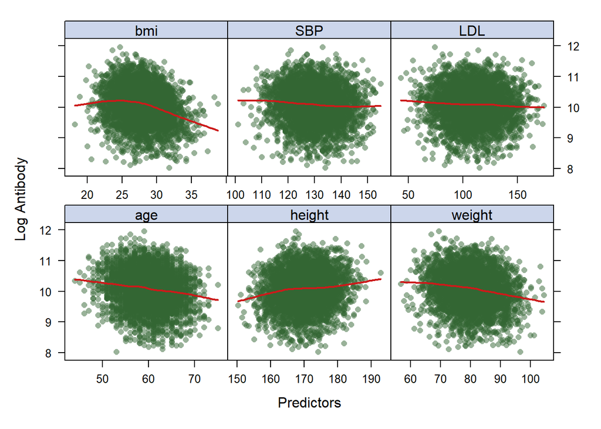

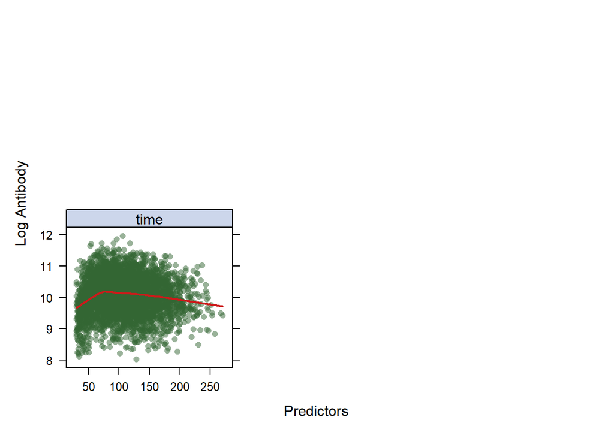

```r
## Set the plotting theme
theme1 <- trellis.par.get()
theme1$plot.symbol$col <- rgb(.2, .4, .2, .5)
theme1$plot.symbol$pch <- 16
theme1$plot.line$col <- rgb(.8, .1, .1, 1)
theme1$plot.line$lwd <- 2
theme1$strip.background$col <- rgb(.0, .2, .6, .2)
trellis.par.set(theme1)

## Feature Plots for numeric predictors (L2)
featurePlot(
  x = training_data[, c("age", "height", "weight", "bmi", "SBP", "LDL", "time")],
  y = training_data$log_antibody,
  plot = "scatter",
  span = 0.5,
  labels = c("Predictors", "Log Antibody"),
  type = c("p", "smooth"),
  layout = c(3, 2)
)
```

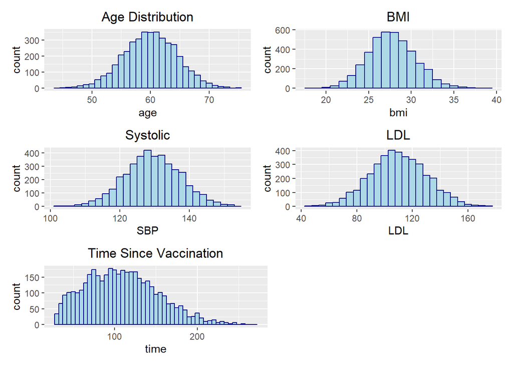

```r
## Histograms for numeric predictors (need to ref code)

# Age histogram
h1 <- ggplot(training_data, aes(x = age)) +
  geom_histogram(binwidth = 1, color = "darkblue", fill = "lightblue") +
  ggtitle("Age Distribution") +
  theme(plot.title = element_text(hjust = 0.5))

# BMI histogram
h2 <- ggplot(training_data, aes(x = bmi)) +
  geom_histogram(binwidth = 1, color = "darkblue", fill = "lightblue") +
  ggtitle("BMI") +
  theme(plot.title = element_text(hjust = 0.5))

# SBP histogram
h3 <- ggplot(training_data, aes(x = SBP)) +
  geom_histogram(binwidth = 2, color = "darkblue", fill = "lightblue") +
  ggtitle("Systolic") +
  theme(plot.title = element_text(hjust = 0.5))

# LDL histogram
h4 <- ggplot(training_data, aes(x = LDL)) +
  geom_histogram(binwidth = 5, color = "darkblue", fill = "lightblue") +
  ggtitle("LDL") +
  theme(plot.title = element_text(hjust = 0.5))

# Time since vaccination histogram
h5 <- ggplot(training_data, aes(x = time)) +
  geom_histogram(binwidth = 5, color = "darkblue", fill = "lightblue") +
  ggtitle("Time Since Vaccination") +
  theme(plot.title = element_text(hjust = 0.5))

# Combine using patchwork
(h1 + h2) / (h3 + h4) / (h5 + plot_spacer())
```

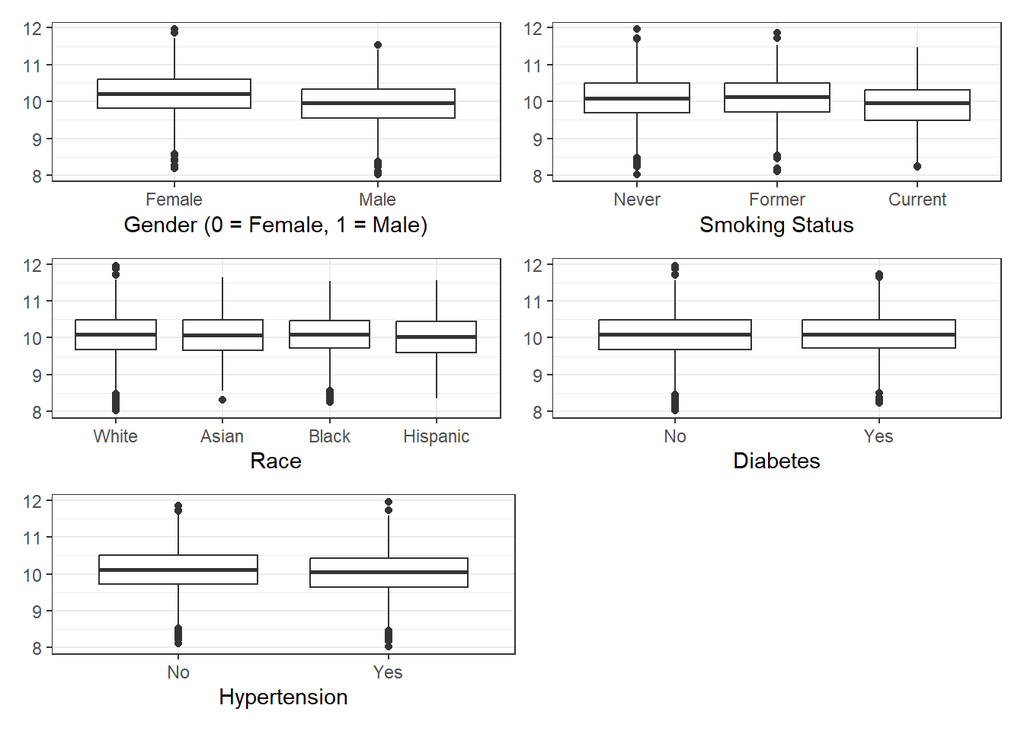

```r
## Boxplots for categorical predictors

p1 <- ggplot(training_data, aes(x = factor(gender), y = log_antibody)) +
  geom_boxplot() +
  labs(x = "Gender (0 = Female, 1 = Male)", y = NULL) +
  theme_bw()

p2 <- ggplot(training_data, aes(x = smoking, y = log_antibody)) +
  geom_boxplot() +
  labs(x = "Smoking Status", y = NULL) +
  theme_bw()

p3 <- ggplot(training_data, aes(x = race, y = log_antibody)) +
  geom_boxplot() +
  labs(x = "Race", y = NULL) +
  theme_bw()

p4 <- ggplot(training_data, aes(x = factor(diabetes), y = log_antibody)) +
  geom_boxplot() +
  labs(x = "Diabetes", y = NULL) +
  theme_bw()

p5 <- ggplot(training_data, aes(x = factor(hypertension), y = log_antibody)) +
  geom_boxplot() +
  labs(x = "Hypertension", y = NULL) +
  theme_bw()

# Using patchwork
((p1 + p2) / (p3 + p4) / (p5 + plot_spacer()))
```

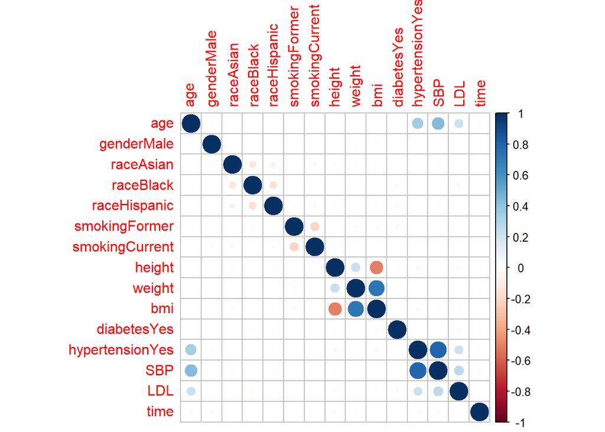

```r
## Correlation Plot

# Matrix of predictors
x <- model.matrix(log_antibody ~ ., training_data)[, -1]

# Vector of response
y <- training_data$log_antibody

# Produce corrplot
corrplot::corrplot(cor(x), method = 'circle', type = 'full')
```

Looking at the correlation plot we see a few predictors are correlated, for example weight and bmi and height and bmi seem to have a decently strong correlation. SBP and hypertension also have correlation. These correlations make sense as BMI uses height and weight to calculate the score, and SBP and hypertension status are linked. Keeping in mind that these correlations among predictors may cause multicollinearity we should consider regularization techniques (lasso/ridge penalties) in our models.

```r
# https://cran.r-project.org/web/packages/table1/vignettes/table1-examples.html

label(training_data$height) <- "Height (cm)"
label(training_data$age) <- "Age (yrs)"
label(training_data$weight) <- "Weight (kgs)"
label(training_data$bmi) <- "Body Mass Index (weight/ (height)^2)"
label(training_data$SBP) <- "Systolic blood pressure (mmHg)"
label(training_data$LDL) <- "LDL cholestrol (mg/dL)"
label(training_data$time) <- "Time since vaccination (in days)"
label(training_data$gender) <- "Gender"
label(training_data$race) <- "Race"
label(training_data$smoking) <- "Smoking status"
label(training_data$diabetes) <- "Diabetes"
label(training_data$hypertension) <- "Hypertension"



table1= table1(~ gender + race + age + height + weight + bmi + SBP + LDL+ time +
         smoking + diabetes + hypertension, data=training_data)
knitr::kable(table1)
```

|  | Overall |
| --- | --- |
|  | (N=4000) |
| Gender |  |
| Female | 2057 (51.4%) |
| Male | 1943 (48.6%) |
| Race |  |
| White | 2599 (65.0%) |
| Asian | 226 (5.7%) |
| Black | 816 (20.4%) |
| Hispanic | 359 (9.0%) |
| Age (yrs) |  |
| Mean (SD) | 60.0 (4.51) |
| Median [Min, Max] | 60.0 [44.0, 75.0] |
| Height (cm) |  |
| Mean (SD) | 170 (5.94) |
| Median [Min, Max] | 170 [150, 193] |
| Weight (kgs) |  |
| Mean (SD) | 80.2 (7.03) |
| Median [Min, Max] | 80.1 [56.7, 104] |
| Body Mass Index (weight/ (height)^2) |  |
| Mean (SD) | 27.8 (2.75) |
| Median [Min, Max] | 27.6 [18.2, 38.8] |
| Systolic blood pressure (mmHg) |  |
| Mean (SD) | 130 (7.98) |
| Median [Min, Max] | 130 [101, 155] |
| LDL cholestrol (mg/dL) |  |
| Mean (SD) | 110 (20.2) |
| Median [Min, Max] | 110 [43.0, 174] |
| Time since vaccination (in days) |  |
| Mean (SD) | 109 (43.8) |
| Median [Min, Max] | 106 [30.0, 270] |
| Smoking status |  |
| Never | 2404 (60.1%) |
| Former | 1214 (30.4%) |
| Current | 382 (9.6%) |
| Diabetes |  |
| No | 3385 (84.6%) |
| Yes | 615 (15.4%) |
| Hypertension |  |
| No | 2142 (53.6%) |
| Yes | 1858 (46.5%) |

Based on the exploratory analysis of continuous predictors, time since vaccination appears to be right-skewed.

# Model Selection

## Linear Regression

```r
# Set seed for reproducibility
set.seed(299)

# linear regression
ctrl1 <- trainControl(method = "cv", number = 10)

# Fit linear model
lm.fit <- train(log_antibody ~ .,
                data = training_data,
                method = "lm",
                trControl = ctrl1)

# model summary
summary_model <- summary(lm.fit$finalModel)
print(summary_model)
```

```
##
## Call:
## lm(formula = .outcome ~ ., data = dat)
##
## Residuals:
##      Min       1Q   Median       3Q      Max
## -2.14518 -0.35746  0.02501  0.38165  1.63778
##
## Coefficients:
##                   Estimate Std. Error t value Pr(>|t|)
## (Intercept)      2.930e+01  2.580e+00  11.357  < 2e-16 ***
## age             -2.082e-02  2.149e-03  -9.686  < 2e-16 ***
## genderMale      -2.957e-01  1.739e-02 -17.002  < 2e-16 ***
## raceAsian        5.675e-03  3.814e-02   0.149   0.8817
## raceBlack        8.053e-03  2.206e-02   0.365   0.7151
## raceHispanic    -4.568e-02  3.095e-02  -1.476   0.1400
## smokingFormer    2.537e-02  1.935e-02   1.311   0.1900
## smokingCurrent  -2.016e-01  3.029e-02  -6.656 3.20e-11 ***
## height          -9.742e-02  1.509e-02  -6.454 1.22e-10 ***
## weight           1.012e-01  1.596e-02   6.340 2.56e-10 ***
## bmi             -3.421e-01  4.596e-02  -7.442 1.20e-13 ***
## diabetesYes      2.319e-02  2.410e-02   0.962   0.3360
## hypertensionYes -3.392e-02  2.905e-02  -1.167   0.2431
## SBP              1.433e-03  1.899e-03   0.755   0.4505
## LDL             -4.142e-05  4.486e-04  -0.092   0.9264
## time            -3.748e-04  1.986e-04  -1.887   0.0592 .
## ---
## Signif. codes:  0 '***' 0.001 '**' 0.01 '*' 0.05 '.' 0.1 ' ' 1
##
## Residual standard error: 0.5489 on 3984 degrees of freedom
## Multiple R-squared:  0.1546, Adjusted R-squared:  0.1515
## F-statistic: 48.58 on 15 and 3984 DF,  p-value: < 2.2e-16
```

The first model we will try is multiple linear regression. This strength of this model lays in its simplicity and interpretability, so if later we find it performs the best it would be the ideal choice. However, from our EDA earlier we already have an idea that a linear model may not be the best since none of the pdps show a clear linear trend implying there may be more complexities to consider. Also, as shown in our correlation matrix, there may be correlation among predictors (e.g. height/weight and bmi) which we may want to consider through use of more complex models that have regularization penalities. The summary shows us the significant predictors in our multiple linear regression are age, gender, smoking status, height, weight and bmi.

## Elastic Net

```r
set.seed(299)
enet_fit <- train(log_antibody ~ ., data = training_data, method = "glmnet",
            tuneGrid = expand.grid(alpha = seq(0, 1, length = 21),
            lambda = exp(seq(-3, 3, length = 100))),
            trControl = ctrl1)

enet_fit$bestTune
```

```
##     alpha     lambda
## 101  0.05 0.04978707
```

```r
# Checking to see if it is in the grid or not
best_lambda <- enet_fit$bestTune$lambda
lambda_range <- range(enet_fit$results$lambda)

print(best_lambda)
```

```
## [1] 0.04978707
```

```r
print(format(lambda_range, scientific = FALSE))
```

```
## [1] " 0.04978707" "20.08553692"
```

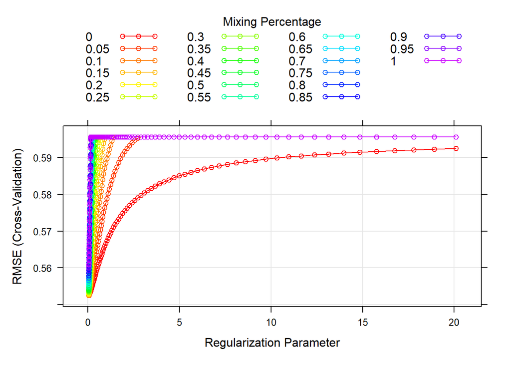

```r
myCol <- rainbow(25)
myPar <- list(superpose.symbol = list(col = myCol),
              superpose.line = list(col = myCol))

plot(enet_fit, par.settings = myPar)
```

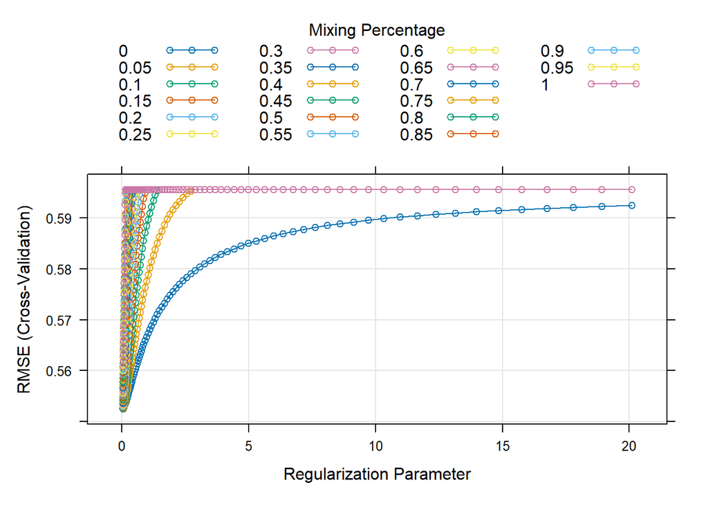

```r
plot(enet_fit, xvar = "lambda", label = TRUE)
```

## PCR

```r
set.seed(299)
pcr_mod <- pcr(log_antibody ~ .,
data = training_data,
scale = TRUE, # scale = FALSE by default
validation = "CV")
summary(pcr_mod)
```

```
## Data:    X dimension: 4000 15
##  Y dimension: 4000 1
## Fit method: svdpc
## Number of components considered: 15
##
## VALIDATION: RMSEP
## Cross-validated using 10 random segments.
##        (Intercept)  1 comps  2 comps  3 comps  4 comps  5 comps  6 comps
## CV          0.5959   0.5937   0.5788   0.5772   0.5772    0.577   0.5761
## adjCV       0.5959   0.5937   0.5788   0.5772   0.5772    0.577   0.5762
##        7 comps  8 comps  9 comps  10 comps  11 comps  12 comps  13 comps
## CV      0.5693   0.5655   0.5580    0.5583    0.5582    0.5583    0.5532
## adjCV   0.5697   0.5655   0.5579    0.5582    0.5581    0.5582    0.5531
##        14 comps  15 comps
## CV       0.5532    0.5501
## adjCV    0.5531    0.5500
##
## TRAINING: % variance explained
##               1 comps  2 comps  3 comps  4 comps  5 comps  6 comps  7 comps
## X              14.800   26.712   34.999    43.13   50.823   57.996   64.748
## log_antibody    0.803    5.782    6.338     6.38    6.448    6.824    8.919
##               8 comps  9 comps  10 comps  11 comps  12 comps  13 comps
## X               71.42    77.91     83.73     89.09     93.96     98.70
## log_antibody    10.14    12.73     12.73     12.81     12.81     14.43
##               14 comps  15 comps
## X                99.99    100.00
## log_antibody     14.47     15.46
```

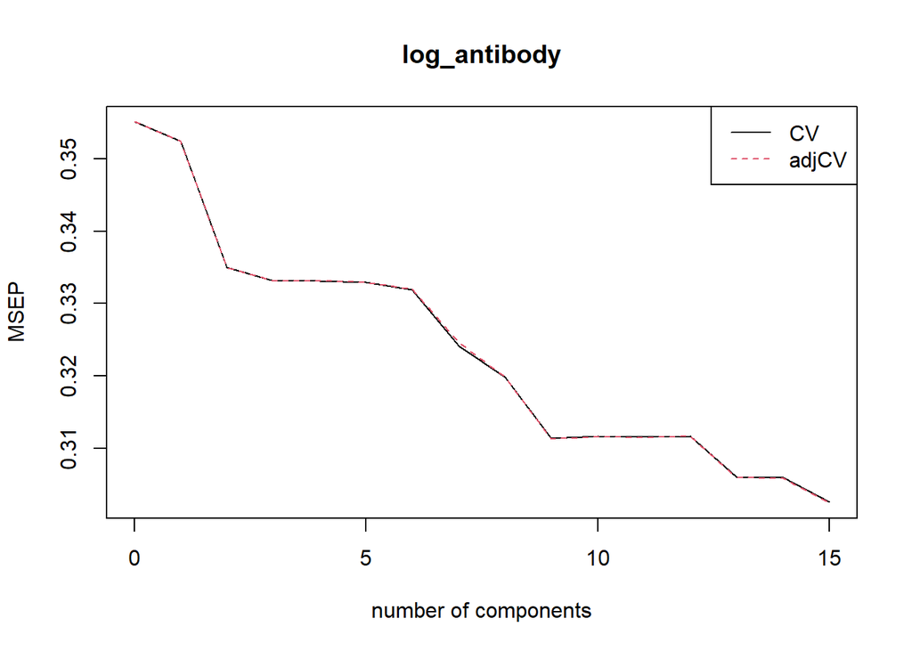

```r
# plot cross-validated mean squared error (MSEP)
validationplot(pcr_mod, val.type = "MSEP", legendpos = "topright")
```

```r
# determine the optimal number of components
cv_mse <- RMSEP(pcr_mod)
ncomp_cv <- which.min(cv_mse$val[1,,]) - 1
ncomp_cv
```

```
## 15 comps
##       15
```

## PCR

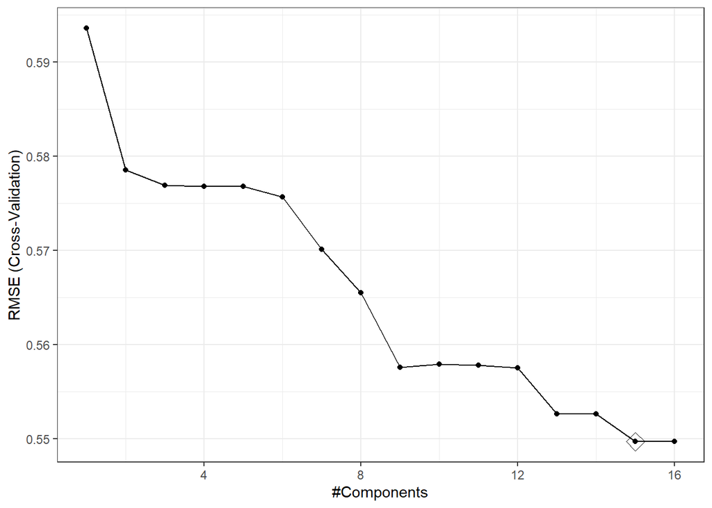

```r
set.seed(299)
pcr_fit <- train(x, y,
                 method = "pcr",
                 tuneGrid = data.frame(ncomp = 1:16),
                 trControl = ctrl1,
                 preProcess = c("center", "scale"))

# Plot
ggplot(pcr_fit, highlight = TRUE) + theme_bw()
```

We fit the PCR model using the function pcr(). PCR and PLS models are good for addressing multicollinearity by maximizing the variance of predictor variables.

## PLS

```r
set.seed(299)

# Checking initial grid range while fitting PLS model
# pls_fit <- train(
#  x = x,
#  y = y,
#  method = "pls",
#  tuneGrid = data.frame(ncomp = 1:8),
#  trControl = ctrl1,
 # preProcess = c("center", "scale")
#)

# Expanded grid to check more
pls_fit <- train(
  x = x,
  y = y,
  method = "pls",
  tuneGrid = data.frame(ncomp = 1:13),
  trControl = ctrl1,
  preProcess = c("center", "scale")
)

# Summary of model
summary(pls_fit)
```

```
## Data:    X dimension: 4000 15
##  Y dimension: 4000 1
## Fit method: oscorespls
## Number of components considered: 9
## TRAINING: % variance explained
##           1 comps  2 comps  3 comps  4 comps  5 comps  6 comps  7 comps
## X           10.79    19.95    31.82    38.39    43.52    47.61    53.55
## .outcome    12.89    14.35    14.45    14.47    14.49    14.52    14.64
##           8 comps  9 comps
## X           54.97    60.84
## .outcome    15.40    15.46
```

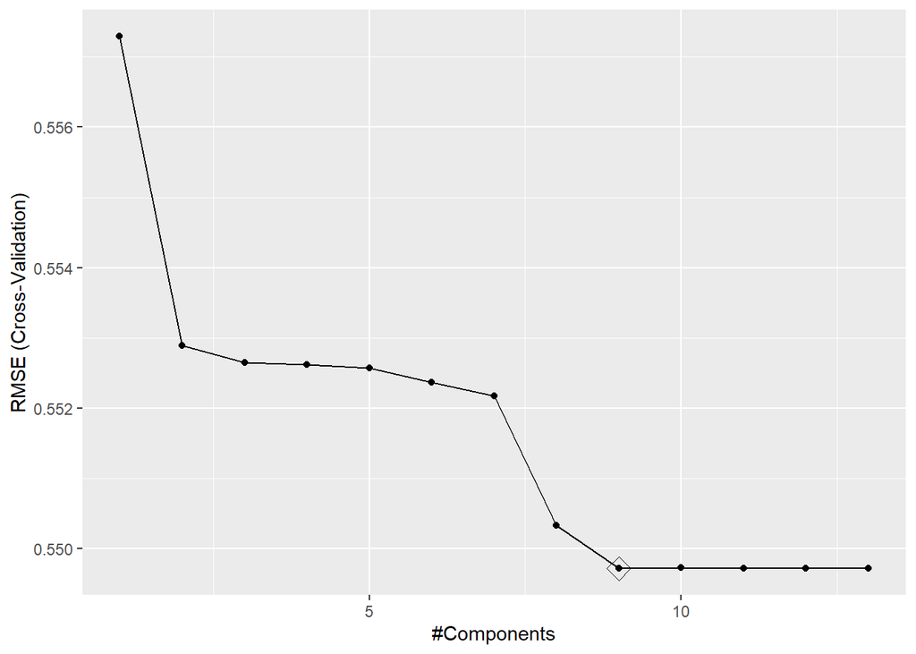

```r
# Visualize
ggplot(pls_fit, highlight = TRUE)
```

We fit an elastic net model using the train() with method = “glmnet” function. Elastic net models are good for effectively dealing with highly correlated groups of predictors.

## MARS - Naomi

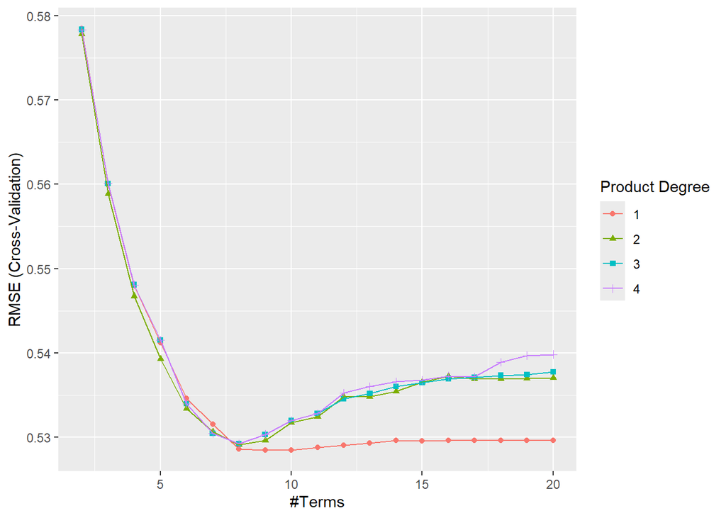

```r
# Set seed for reproducibility
set.seed(299)

# Specify MARS grid - first attempt
# mars_grid <- expand.grid(
#  degree = 1:3, # degree of interactions
#  nprune = 2:15  # no. of retained terms
# )

# MARS tuning grid - expanding grid
mars_grid <- expand.grid(
  degree = 1:4,     # interaction degrees
  nprune = 2:20     # number of terms
)

# Train MARS model to predict log_antibody
mars.fit <- train(log_antibody ~ .,
                  data = training_data,
                  method = "earth",
                  tuneGrid = mars_grid,
                  trControl = ctrl1)

# Plot CV performance
ggplot(mars.fit)
```

```r
# Optimal parameters
mars.fit$bestTune
```

```
##   nprune degree
## 9     10      1
```

```r
# Final model coefficients
mars_coef <- coef(mars.fit$finalModel)

mars_coef
```

```
##    (Intercept)    h(27.9-bmi)     genderMale     h(time-58)     h(58-time)
##   10.889616214   -0.079894291   -0.294580056   -0.002294482   -0.030650939
##      h(age-59)      h(59-age) smokingCurrent    h(bmi-23.6)   h(74-weight)
##   -0.024586248    0.016630875   -0.219147187   -0.088204579    0.015815012
```

As the interaction `degree` increased, RMSE values became more variable rather than decreasing steadily, suggesting there was no gain in prediction accuracy. The `nprune` range of 2 to 20 also appeared appropriate — RMSE decreased initially with more terms but then plateaued, indicating that adding further complexity would not significantly improve model performance. Based on this, I selected `degree = 1` as the optimal choice.

**Optimal parameters and final model coefficients** The best-tuned model selected `degree = 1` and `nprune =`10`. Therefore, the final model includes 10 retained terms with no interaction effects.

## GAM

I will proceed with constructing a GAM model, allowing us to mix non-linear and linear terms and build a model estimating the relationship between the outcome (`log_antibody`) and predictors in the provided dataset.

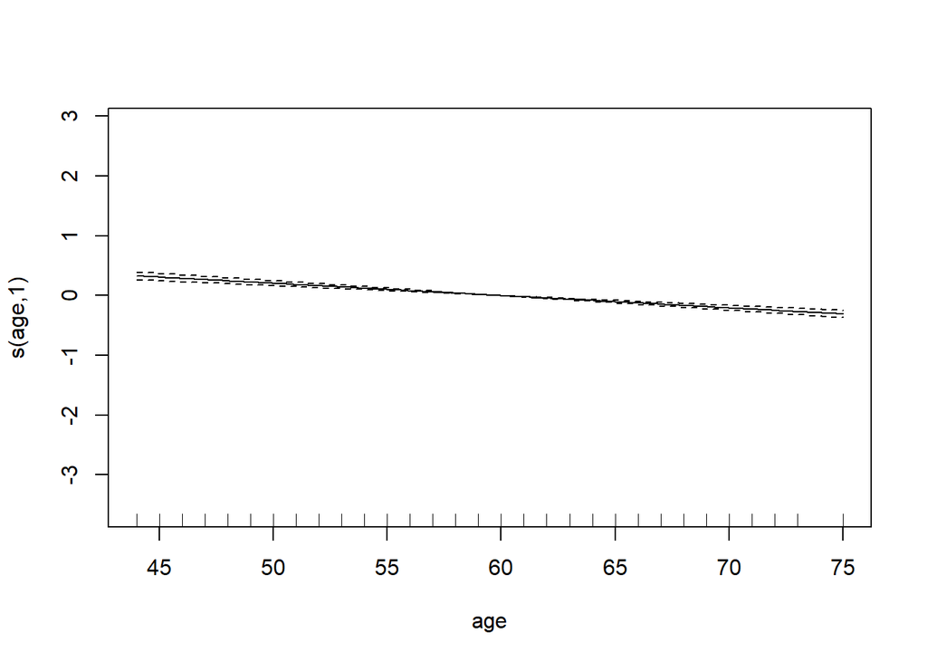

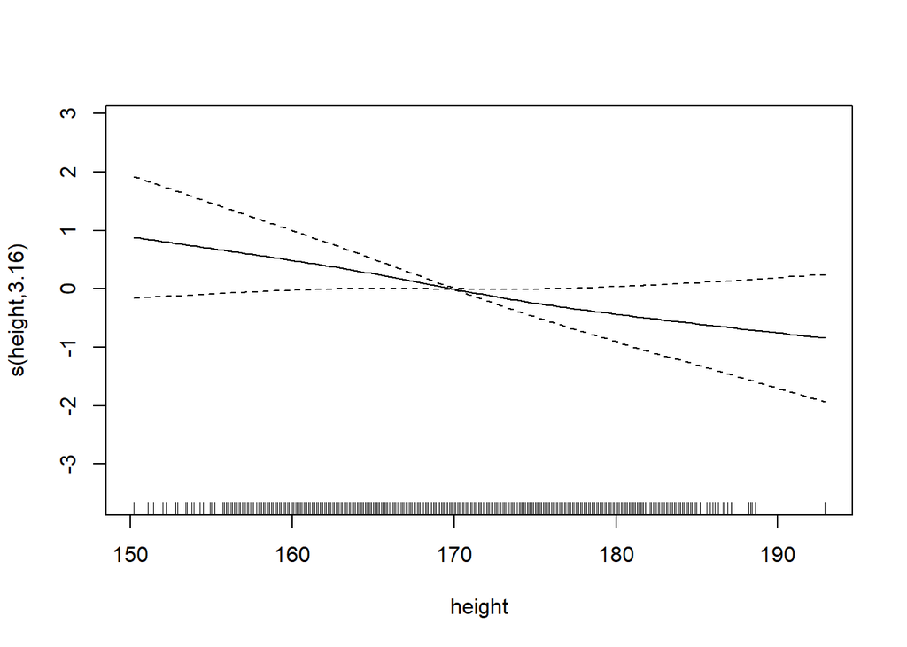

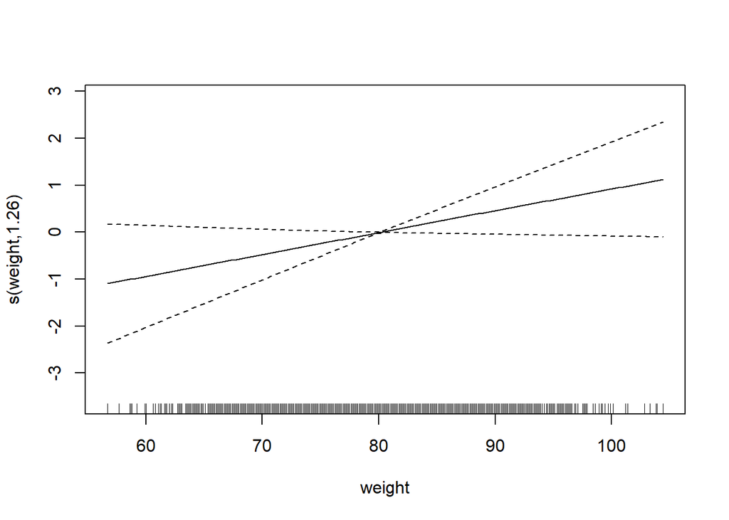

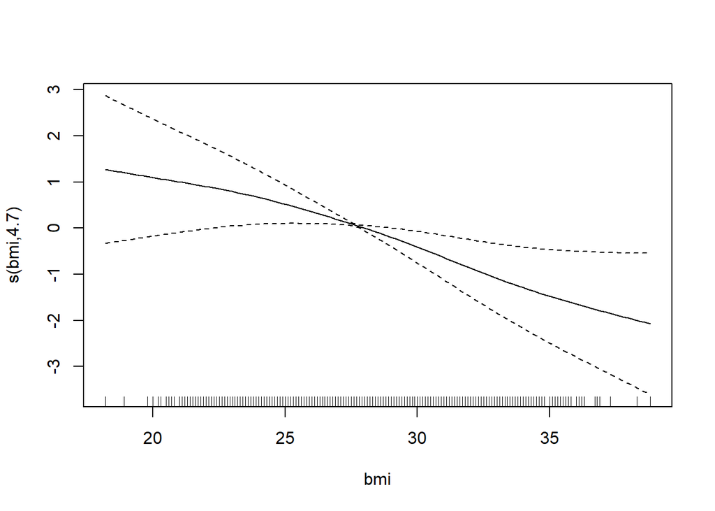

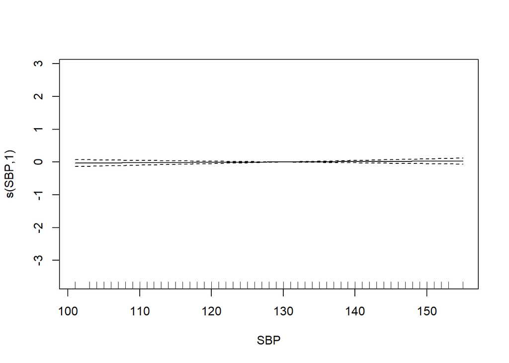

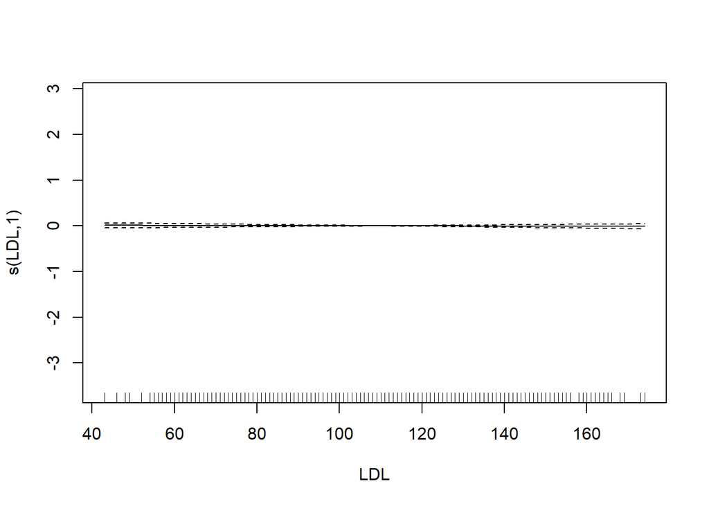

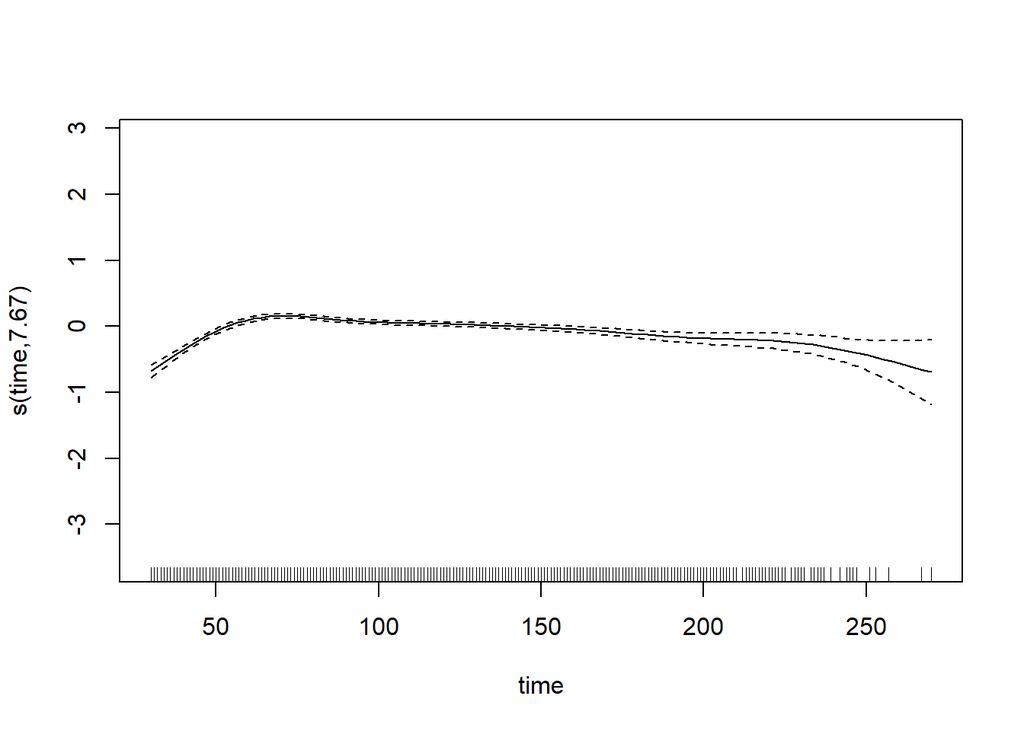

```r
# Set seed for reproducibility
set.seed(299)

# Fit a GAM model, using training data
gam_antibody <- gam(log_antibody ~ gender + race +
                      smoking + s(age) +
                      s(height) + s(weight) + s(bmi) +
                      diabetes + hypertension + s(SBP) +
                      s(LDL) + s(time),
                    data = training_data)

# Plot GAM predictors
plot(gam_antibody)
```

```r
# Use train() from caret to fit GAM Model

gam.fit <- train(
  log_antibody ~ gender + race +
    smoking + age +
    height + weight + bmi + diabetes +
    hypertension + SBP +
    LDL + time,
  data = training_data,
  method = "gam",
  trControl = ctrl1
)

# Predictor EDF values from mgcv fitted GAM model
summary(gam_antibody)
```

```
##
## Family: gaussian
## Link function: identity
##
## Formula:
## log_antibody ~ gender + race + smoking + s(age) + s(height) +
##     s(weight) + s(bmi) + diabetes + hypertension + s(SBP) + s(LDL) +
##     s(time)
##
## Parametric coefficients:
##                  Estimate Std. Error t value Pr(>|t|)
## (Intercept)     10.236488   0.019637 521.276  < 2e-16 ***
## genderMale      -0.293528   0.016717 -17.558  < 2e-16 ***
## raceAsian        0.010065   0.036670   0.274    0.784
## raceBlack        0.002428   0.021208   0.114    0.909
## raceHispanic    -0.040796   0.029745  -1.372    0.170
## smokingFormer    0.023783   0.018598   1.279    0.201
## smokingCurrent  -0.207937   0.029143  -7.135 1.14e-12 ***
## diabetesYes      0.018722   0.023157   0.808    0.419
## hypertensionYes -0.035357   0.027923  -1.266    0.206
## ---
## Signif. codes:  0 '***' 0.001 '**' 0.01 '*' 0.05 '.' 0.1 ' ' 1
##
## Approximate significance of smooth terms:
##             edf Ref.df      F p-value
## s(age)    1.000  1.000 98.987  <2e-16 ***
## s(height) 3.163  4.027  2.513  0.0395 *
## s(weight) 1.255  1.460  3.443  0.1166
## s(bmi)    4.700  5.770 15.333  <2e-16 ***
## s(SBP)    1.000  1.000  0.398  0.5284
## s(LDL)    1.000  1.000  0.120  0.7289
## s(time)   7.665  8.446 35.692  <2e-16 ***
## ---
## Signif. codes:  0 '***' 0.001 '**' 0.01 '*' 0.05 '.' 0.1 ' ' 1
##
## R-sq.(adj) =  0.218   Deviance explained = 22.4%
## GCV = 0.27952  Scale est. = 0.27751   n = 4000
```

- Some predictors have estimated degrees of freedom (edf) greater than 1, specifically height, weight, BMI, and time, indicating they are modeled as nonlinear smooth functions. This is supported by the GAM predictor plots. Weight, while slightly above 1, was not statistically significant, and does not show strong evidence of nonlinearity.
- Age, SBP, and LDL each have an edf of exactly 1.00, indicating that they are modeled as approximately linear. Of these, only age was statistically significant (p < 2e-16), suggesting a strong linear association with log antibody levels.
- Among the nonlinear terms, height, BMI, and time were statistically significant (p < 0.05), indicating meaningful nonlinear relationships with the outcome.

# Comparison/Model selection

```r
# Compare models using cross-validated RMSE
resamp <- resamples(list(
  linear = lm.fit,
  pls = pls_fit,
  pcr = pcr_fit,
  elastic_net = enet_fit,
  mars = mars.fit,
  gam = gam.fit))

# Print CV summary
summary(resamp)
```

```
##
## Call:
## summary.resamples(object = resamp)
##
## Models: linear, pls, pcr, elastic_net, mars, gam
## Number of resamples: 10
##
## MAE
##                  Min.   1st Qu.    Median      Mean   3rd Qu.      Max. NA's
## linear      0.4218816 0.4306542 0.4384917 0.4380951 0.4420410 0.4643759    0
## pls         0.4218879 0.4305666 0.4384413 0.4381286 0.4420845 0.4644527    0
## pcr         0.4218816 0.4306542 0.4384917 0.4380951 0.4420410 0.4643759    0
## elastic_net 0.4259547 0.4308305 0.4420923 0.4402386 0.4452870 0.4646995    0
## mars        0.4087612 0.4162982 0.4194019 0.4223325 0.4246097 0.4482083    0
## gam         0.4090844 0.4154067 0.4190308 0.4224680 0.4243278 0.4509068    0
##
## RMSE
##                  Min.   1st Qu.    Median      Mean   3rd Qu.      Max. NA's
## linear      0.5291211 0.5422187 0.5455445 0.5497246 0.5563390 0.5804557    0
## pls         0.5290925 0.5420742 0.5454616 0.5497178 0.5564140 0.5803725    0
## pcr         0.5291211 0.5422187 0.5455445 0.5497246 0.5563390 0.5804557    0
## elastic_net 0.5338862 0.5434377 0.5504881 0.5524924 0.5595791 0.5822864    0
## mars        0.5079689 0.5207260 0.5255350 0.5284505 0.5318190 0.5595607    0
## gam         0.5116175 0.5211185 0.5246030 0.5287282 0.5291460 0.5633231    0
##
## Rsquared
##                  Min.   1st Qu.    Median      Mean   3rd Qu.      Max. NA's
## linear      0.1186222 0.1352508 0.1408950 0.1497900 0.1733672 0.1818408    0
## pls         0.1179362 0.1349088 0.1411335 0.1498139 0.1733948 0.1813984    0
## pcr         0.1186222 0.1352508 0.1408950 0.1497900 0.1733672 0.1818408    0
## elastic_net 0.1109663 0.1280339 0.1374457 0.1414224 0.1520943 0.1770563    0
## mars        0.1706097 0.2095416 0.2140967 0.2139887 0.2285973 0.2346068    0
## gam         0.1644471 0.2089414 0.2186226 0.2135257 0.2247913 0.2454105    0
```

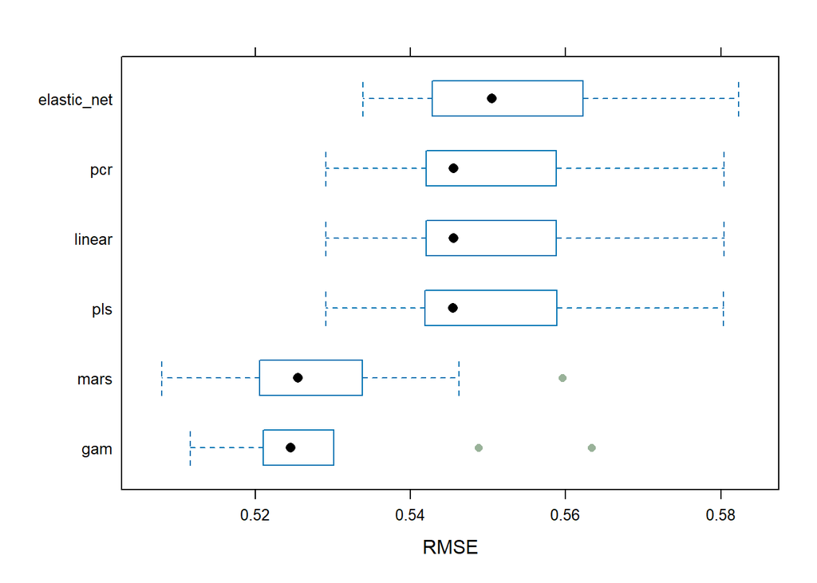

```r
# Plot RMSE comparison
bwplot(resamp, metric = "RMSE")
```

MARS has the smallest mean RMSE (`0.5284505`), therefore we select it as the optimal model.

We will first evaluate its performance based on the testing dataset.

```r
# Set seed for reproducibility
set.seed(299)

# Obtain response variable from testing data
y_testing_MARS <- testing_data$log_antibody

# Predict on test data using trained MARS model
y_pred_MARS <- predict(mars.fit, newdata = testing_data)

# Compute RMSE (Test Error)
test_rmse <- sqrt(mean((y_testing_MARS - y_pred_MARS)^2))

# Print test RMSE
test_rmse
```

```
## [1] 0.5269679
```

Therefore, the test error for the MARS model is `0.5269679`.

# Test Error for Selected Model Applied to New Dataset: MARS

Subsequently, we want to evaluate the generalizability of this model using another independent dataset, (`dat2`)`.

```r
# Set seed for reproducibility
set.seed(299)

# Obtain response variable from dat2
y_testing_DAT2 <- dat2$log_antibody

# Predict on dat2 using trained MARS model
y_pred_DAT2 <- predict(mars.fit, newdata = dat2)

# Compute RMSE (Test Error)
test_rmse <- sqrt(mean((y_testing_DAT2 - y_pred_DAT2)^2))

# Print test RMSE
test_rmse
```

```
## [1] 0.5335579
```

The test error for the MARS model when fit on the new dataset (`dat2`) is `0.5335579`.